# Ex4

Nadav Weisler - 316493758, Gaya Aran - 209636885

```r
# setwd("SOME_PATH")
```

```r
require(ggplot2)
require(report)
require(effectsize)
require(dplyr)
require(emmeans)
require(pwr)
require(sjPlot)
require(ggeffects)
```

## Part 1

```r
df = read.csv("ex4_data.csv")
```

### Question 1

#### a

We need 101 subjects for power of 80%.

```r
r2_a = 0.18
r2_ab = 0.24
u = 1

f2 = ((r2_ab - r2_a) / (1 - r2_ab))
pwr_result = pwr.f2.test(u = u, f2 = f2, sig.level = 0.05, power = 0.8)
subject_count = round(pwr_result$v) + u + 1
subject_count
```

```
## [1] 101
```

#### b

```r
df$personality = as.factor(df$personality)
contrasts(df$personality)[1,] = -1
df$caffeine = as.numeric(scale(df$caffeine))
```

#### c

```r
model_1_1 = lm(PS_score ~ caffeine * personality + age, df)
table_1_1 = tab_model(model_1_1, show.df = T, show.stat = T)
table_1_1
```

|  | PS_score |  |  |  |  |
| --- | --- | --- | --- | --- | --- |
| Predictors | Estimates | CI | Statistic | p | df |
| (Intercept) | 189.75 | 167.03 – 212.47 | 16.48 | **<0.001** | 185.00 |
| caffeine | 19.23 | 13.87 – 24.60 | 7.07 | **<0.001** | 185.00 |
| personality [introverted] | -17.98 | -23.32 – -12.64 | -6.65 | **<0.001** | 185.00 |
| age | -0.35 | -1.05 – 0.35 | -0.99 | 0.323 | 185.00 |
| caffeine × personality [introverted] | -6.95 | -12.31 – -1.59 | -2.56 | **0.011** | 185.00 |
| Observations | 190 |  |  |  |  |
| R<sup>2</sup> / R<sup>2</sup> adjusted | 0.354 / 0.340 |  |  |  |  |

#### d

There is no need to worry about multicollinearity because the variance inflation factors (VIF) for our model’s predictors are all below the threshold of 5 (around 1)

```r
car::vif(model_1_1)
```

```
## there are higher-order terms (interactions) in this model
## consider setting type = 'predictor'; see ?vif
```

```
##             caffeine          personality                  age
##             1.007379             1.001946             1.002468
## caffeine:personality
##             1.005125
```

#### e

By our data we can understand that introvertion and caffeine effect public speaking, and caffeine effect more on extrovert peoples.

#### f

Age could be a confound or external variable, that might effect the results. For instance, the effect of caffeine on bodily arousal and consequently on performance (such as public speaking) may change with age. Adding it helps us to control its possible influence and the noise in the results it could create.

#### g

Create an informative graph visualizing the model predictions (using ggpredict as shown in the tutorial). The graph should be focused on the two effects that were hypothesized, while considering the controlled variable (so if there was an effect, the graph should make it visible).

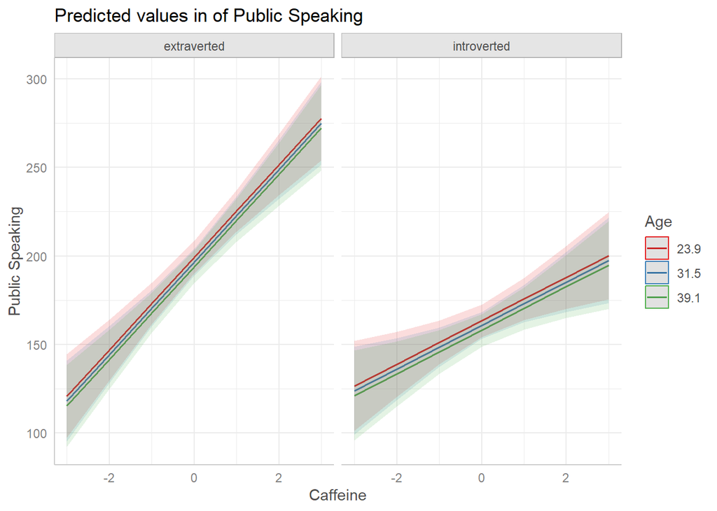

```r
plot(ggpredict(model_1_1, terms=c("caffeine", "age", "personality"))) +
 labs(
    x = "Caffeine",
    y = "Public Speaking",
    title = "Predicted values in of Public Speaking",
    colour = "Age"
  )
```

### Question 2

#### a

```r
model_1_2 = lm(PS_score ~ (caffeine * arousal), df)
tab_model(model_1_2)
```

|  | PS_score |  |  |
| --- | --- | --- | --- |
| Predictors | Estimates | CI | p |
| (Intercept) | 6.68 | -21.50 – 34.87 | 0.640 |
| caffeine | -21.87 | -40.82 – -2.93 | **0.024** |
| arousal | 18.15 | 15.19 – 21.11 | **<0.001** |
| caffeine × arousal | 2.04 | 0.18 – 3.91 | **0.032** |
| Observations | 190 |  |  |
| R<sup>2</sup> / R<sup>2</sup> adjusted | 0.539 / 0.532 |  |  |

## Part 2

### Question 1

```r
muller_Lyer = read.csv("Muller_Lyer_S2.csv")
print("Init count: ")
```

```
## [1] "Init count: "
```

```r
print(nrow(muller_Lyer))
```

```
## [1] 279
```

```r
muller_Lyer$length_diff = muller_Lyer$length_diff * 100

muller_Lyer$left_arrow = as.factor(muller_Lyer$left_arrow)
contrasts(muller_Lyer$left_arrow)[1,] = -1

muller_Lyer["scaled_rt"] = scale(muller_Lyer$RT)
muller_Lyer = subset(muller_Lyer, abs(scaled_rt) <= 2.5)

print("After clean count: ")
```

```
## [1] "After clean count: "
```

```r
print(nrow(muller_Lyer))
```

```
## [1] 268
```

From 279 trials 268 left.

### Question 2

```r
model_2 = glm(response ~ left_arrow + length_diff, data = muller_Lyer,
              family = "binomial")
tab_model(model_2, show.se = T, show.stat = T, show.fstat = T)
```

|  | response |  |  |  |  |
| --- | --- | --- | --- | --- | --- |
| Predictors | Odds Ratios | std. Error | CI | Statistic | p |
| (Intercept) | 0.33 | 0.08 | 0.20 – 0.54 | -4.33 | **<0.001** |
| left arrow [outward] | 34.99 | 17.67 | 14.61 – 107.73 | 7.04 | **<0.001** |
| length diff | 4.20 | 0.96 | 2.81 – 6.93 | 6.27 | **<0.001** |
| Observations | 268 |  |  |  |  |
| R<sup>2</sup> Tjur | 0.688 |  |  |  |  |

### Question 4

[figure not shown]

```r
plot(ggpredict(model_2, terms=c("left_arrow", "length_diff"))) +
  labs(
    x = "Arrow Direction",
    y = "RT",
    title = "Predicted probabilities of RT",
    colour = "Length difference"
  )
```